# MSDS 6306_Live Session Assignment Unit 05

Sanjay Kalluvilayil

June 15, 2017

Assignment: The assignment is to take the live session unit 04 assignment questions 01-04 and put it into R Markdown. I have used RStudio for the markdown document.

Directionos Formatting can be basic just needs to be legible and it needs to knit to an HTML document. Post the HTML document under Assignments and Grading : Live Session Assignment Unit 05

## Calculation Questions (using R); Use R to calculate the following:

1. Basic Math
1. The log of a positive number.

```r
log(10);
```

```
## [1] 2.302585
```

```r
log(100);
```

```
## [1] 4.60517
```

### b. What is the default base for the log function?

[output not shown]

### Calculate the log of your previous number with a different base.

```r
log10(10);
```

```
## [1] 1
```

```r
log2(10);
```

```
## [1] 3.321928
```

### c. The log of a negative number. (explain the answer)

```r
log(-10);
```

```
## [1] NaN
```

–> NaN means ‘Not a Number’, you can not take the log of a negative number. It must be a positive number.

### d. The square-root of a positive number.

```r
sqrt(16);
```

```
## [1] 4
```

### 2. Random number generation.

```
a. Create a vector of 15 standard normal random variables. Calculate its mean and SD.
```

```r
x <- rnorm (15);
x;
```

```
##  [1] -1.0201593  0.7860395 -0.2843320 -0.9763531 -0.5134761 -0.0488774
##  [7]  1.1159105 -0.4322365 -0.2640464  2.6407189  0.4233194 -0.2029457
## [13]  0.8868944 -0.2281745 -0.3249205
```

```r
mean(x)
```

```
## [1] 0.1038241
```

```r
sd(x);
```

```
## [1] 0.9425215
```

### b. Change the mean to 10 and the SD to 2 and recalculate the vector of 15 random normal variables. Calculate its mean and SD.

```r
x <- rnorm (15, mean=10, sd=2);
x;
```

```
##  [1] 11.470309  8.454585  8.977171  8.767243  9.876920 10.317789  7.975641
##  [8] 10.085157 11.690091 12.897209 11.120099 11.368222  9.192948  6.441794
## [15]  8.893719
```

```r
mean(x)
```

```
## [1] 9.83526
```

```r
sd(x);
```

```
## [1] 1.686992
```

### c. Why are the means and SD not exactly the same as the means and SDs specified in the function?

–> The rnorm takes 15 samples out of a normal population with mean of 10 and SD of 2. The 15 samples will have their own mean and SD. According to Central Limit Theorem, as sample size approaches >30, it will more closely approximate the normal distribution for mean of 10 and SD of 2.

### 3. Vector Operations

```
a. The weights of 6 individuals in kg are 60, 72, 57, 90, 95, 72.
b. Their heights (in m) are 1.80, 1.85, 1.72, 1.90, 1.74, 1.91.
c. Enter these vectors into R.
```

```r
weight <- c(60, 72, 57, 90, 95, 72)
height <- c(1.80, 1.85, 1.72, 1.90, 1.74, 1.91)
weight
```

```
## [1] 60 72 57 90 95 72
```

```r
height
```

```
## [1] 1.80 1.85 1.72 1.90 1.74 1.91
```

### d. Create a scatterplot of weight vs. height. Interpret the scatterplot.

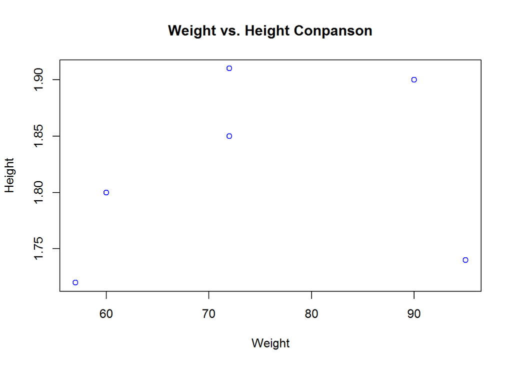

```r
plot(weight, height, main= "Weight vs. Height Conpanson", xlab="Weight", ylab= "Height", col="blue");
```

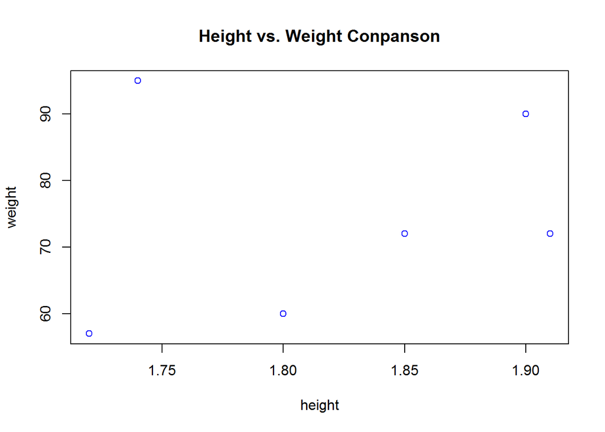

```r
plot(height, weight, main= "Height vs. Weight Conpanson", xlab="height", ylab= "weight", col="blue");
```

### Interpretation –> When we plot weight vs. Height, as weight increases so does height, except for one outlier in the bottom right corner. When we plot Height v. Weight, it shows in general as height increases, so doe weight. There is one outlier up in the left corner.

### e. Calculate the BMI for each individual. (BMI = weight in kg divided by the square of the height in m)

```r
bmi <- weight/ height**2
bmi
```

```
## [1] 18.51852 21.03725 19.26717 24.93075 31.37799 19.73630
```

### f. Calculate the mean for weight.

```r
mean(weight)
```

```
## [1] 74.33333
```

### g. Subtract the mean from each value of weight.

```r
mean <- mean(weight)
mean
```

```
## [1] 74.33333
```

```r
diff <- weight -mean
diff
```

```
## [1] -14.333333  -2.333333 -17.333333  15.666667  20.666667  -2.333333
```

### h. Sum the result. Now you know why we square the deviations from the mean to calculate a standard deviation!

–> It is an extremely small number, which is not an adequate measure of the spread or variance. We square the deviations to eliminate the negative numbers.

```r
sum(diff)
```

```
## [1] 2.842171e-14
```

### 4. Your data science profile.

Enter your data science profile into R as a data frame with two columns. Call it by your first name. The categories are computer programming, math, statistics, machine learning, domain expertise, communication and presentation skills, and data visualization. Your ranking for each category 1 5, with 5 as best. Create a bar graph of your data science profile. When you submit your work, please submit your code, including the data entry piece.

```r
categories <-c("computer programming", "math","statistics", "machine learning", "domain expertise", "communication and presentation skills", "data visualization")
ranking <- c(2,3,2,1,5,4,4)
sanjay <- data.frame(categories, ranking)
sanjay
```

```
##                              categories ranking
## 1                  computer programming       2
## 2                                  math       3
## 3                            statistics       2
## 4                      machine learning       1
## 5                      domain expertise       5
## 6 communication and presentation skills       4
## 7                    data visualization       4
```

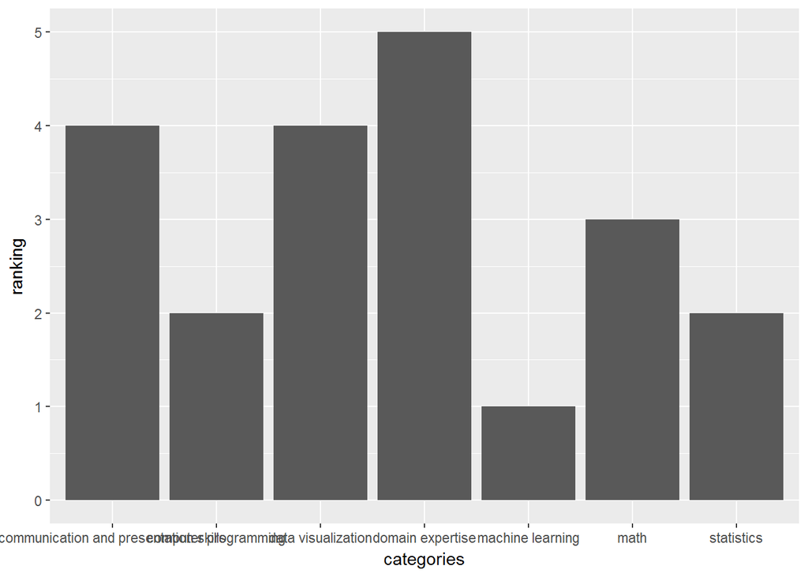

```r
library(ggplot2)
ggplot(data=sanjay, aes(x = categories, y = ranking))+ geom_bar(stat='identity')
```